# LAB 3: Bias/Variance – Exercise

Lluís A. Belanche, translated to R Markdown by Marta Arias

February 2020

## Exercise: Bias/Variance analysis on simulated data

```r
set.seed(5345)
par(mfrow=c(1, 1))
library(polynom)
```

Consider the (unknown) target function $f$ (and best solution to out problem):

```r
f <- function(x) sin(x-5)/(x-5)
```

From which we can sample datasets:

```r
N <- 150
x <- runif(N,0,15)           # generate the x according to a uniform distribution p(x)
t <- f(x) + rnorm(N, sd=0.1) # generate the t according to a gaussian conditional distribution p(t|x)
```

Plot the generated sample along with the (typically unknown) $f$

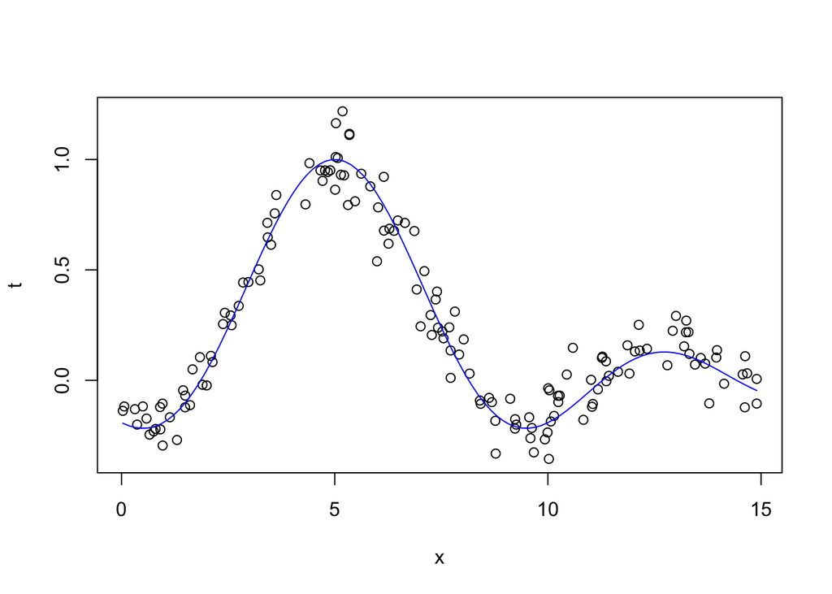

```r
plot(data.frame(x, t))
curve(f, type="l", col="blue", add=TRUE)
```

### Exercise for this lab session:

The exercise consists in estimating bias and variance (and hence bias^2+variance) for different models, and deduce which (polynomial) model is better for this problem.

To this end, you must generate many (thousands?) datasets of size $N$, choose one point $x \in [0,15]$ (I suggest $x=10$) and estimate bias and variance for it. Notice that you do not need to store the datasets. Remember that you can estimate these quantities using the Monte-Carlo method.

The models are going to be polynomials of degrees of your choice (I suggest 1,2,3,4,5,8).

### Models

Recordem que en tot l’exercici suposarem (de fet ho sabem) que els errors segueixen una distribució normal.

Primer generem dades per no treballar amb la mostra de mida 150:

```r
N <- 15
x1 <- runif(N,0,15)     # generate the x according to a uniform distribution p(x)
t1 <- f(x1) + rnorm(N, sd=0.1) # generate the t according to a gaussian conditional distribution p(t|x)
```

#### Polinomi grau 2:

Ara suposem que $t_n \sim {\sf N}(y(x_n; \beta), \sigma)$ on $y(x_n; \beta)$ és un polinomi de grau 2.

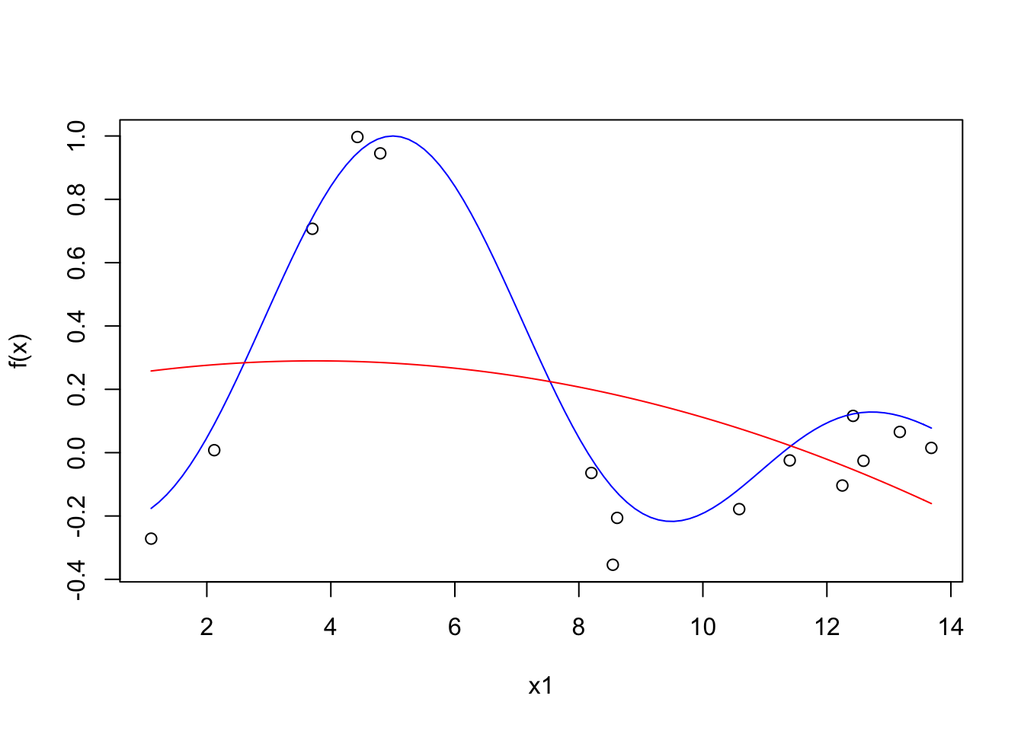

```r
# generem un model que prediu amb un polinomi de grau 2:
poly_2 <- lm(t1 ~ poly(x1, 2, raw=TRUE))
# ho veiem:
plot(data.frame(x1, t1), ylab="f(x)") # punts de les dades
curve(f, type="l", col="blue", add=TRUE) # veritat revelada
p <- as.function(polynomial(coef(poly_2)))
curve(p, col="red", add=TRUE)
```

```r
summary(poly_2)
```

```
##
## Call:
## lm(formula = t1 ~ poly(x1, 2, raw = TRUE))
##
## Residuals:
##      Min       1Q   Median       3Q      Max
## -0.53869 -0.26663 -0.04699  0.17851  0.70908
##
## Coefficients:
##                           Estimate Std. Error t value Pr(>|t|)
## (Intercept)               0.225803   0.423457   0.533    0.604
## poly(x1, 2, raw = TRUE)1  0.034184   0.131544   0.260    0.799
## poly(x1, 2, raw = TRUE)2 -0.004562   0.008429  -0.541    0.598
##
## Residual standard error: 0.4224 on 12 degrees of freedom
## Multiple R-squared:  0.1496, Adjusted R-squared:  0.007906
## F-statistic: 1.056 on 2 and 12 DF,  p-value: 0.3781
```

Ara calculem la variància i el biaix.

```r
mse = function(mod) mean(mod$residuals^2)
mse(poly_2)
```

```
## [1] 0.1427393
```

```r
var(predict(poly_2))
```

```
## [1] 0.02691093
```